# Bay Area Energy Consumption During COVID-19

This report briefly outlines Bay Area energy consumption over the last few years. Due to COVID-19, more people are spending time indoors and completing tasks virtually. In-person experiences, businesses, and work spaces have been shut down. Analyzing PG&E data from the last 4 years can provide insights as to how these lifestyle changes are impacting energy consumption and use.

```r
#Load in Data
quarters <- 1:4
type <- c("Electric","Gas")
years <- 2017:2020
pge_elec_gas <- NULL

for(year in years) {
    for(quarter in quarters) {
     for(ty in type) {
       if(year == 2020 & quarter %in% 3:4) {
        next
       }
       filename <-
         paste0(
           "PGE_",
           year,
           "_Q",
           quarter,
           "_",
           ty,
           "UsageByZip.csv"
         )
       temp <- read_csv(filename)

       ### CONVERTING COLUMNS BY UNIT
       if (ty %in% "Gas") {
         temp <- temp %>%
           mutate(TOTALKBTU = 99*TOTALTHM) %>%
           select(
             -TOTALTHM,
             -AVERAGETHM
           )
       } else {
         temp <- temp %>%
           mutate(TOTALKBTU = 3.412*TOTALKWH) %>%
           select(
             -TOTALKWH,
             -AVERAGEKWH
           )
       }
       pge_elec_gas <- rbind(pge_elec_gas,temp)
       saveRDS(pge_elec_gas, "pge_elec_gas.rds")
     }
      # Note rbind requires field names to be consistent for every new thing that you add.
    }
}
```

```r
#GET BAY ZIP CODES AND GEOMETRIES
ca_counties <- counties("CA", cb = T, progress_bar = F)

bay_county_names <-
  c(
    "Alameda",
    "Contra Costa",
    "Marin",
    "Napa",
    "San Francisco",
    "San Mateo",
    "Santa Clara",
    "Solano",
    "Sonoma"
  )

bay_counties <-
  ca_counties %>%
  filter(NAME %in% bay_county_names)

usa_zips <- zctas(cb = T, progress_bar = F)

bay_zips <-
  usa_zips %>%
  st_centroid() %>%
  .[bay_counties, ] %>%
  st_set_geometry(NULL) %>%
  left_join(usa_zips %>% select(GEOID10)) %>%
  st_as_sf()
```

```r
#MERGE DATA WITH PG&E
pge_final <-
  pge_elec_gas %>%
  filter(
    CUSTOMERCLASS %in%
      c(
        "Elec- Residential",
        "Elec- Commercial",
        "Gas- Residential",
        "Gas- Commercial"
      ),
    ZIPCODE %in% bay_zips$ZCTA5CE10
  ) %>%
  group_by(YEAR, MONTH, CUSTOMERCLASS)

pge_final$DATE <- as.yearmon(paste(pge_final$YEAR, pge_final$MONTH, sep = ":"), "%Y:%m")
```

## Energy Consumption During COVID-19: Month-by-Month Graph

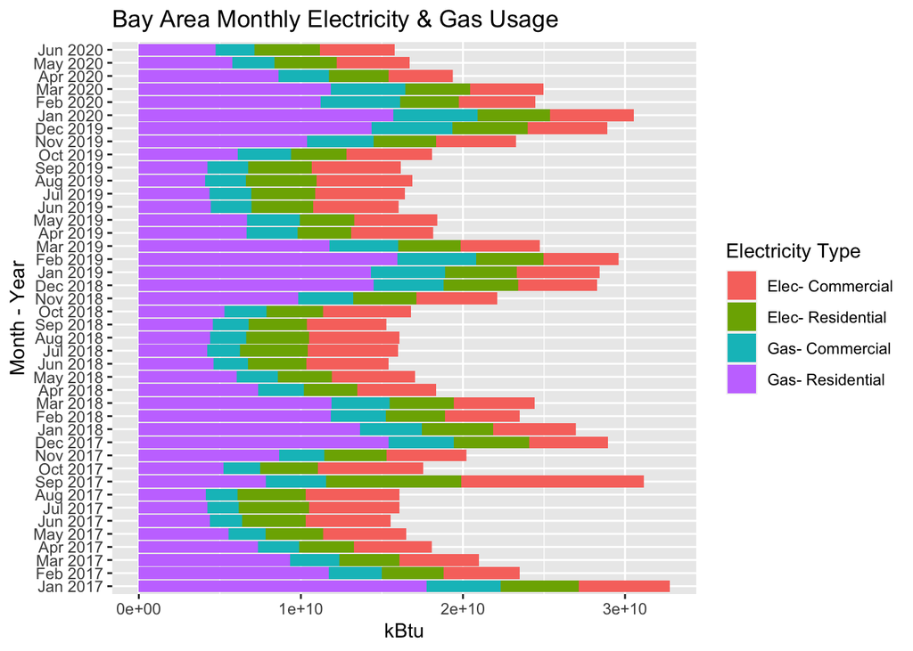

```r
#GRAPH DATA
pge_chart <-
  pge_final %>%
  ggplot() +
  geom_bar(
    aes(
      x = DATE %>% factor(),
      y = TOTALKBTU,
      fill = CUSTOMERCLASS
    ),
    stat = "identity",
    position = "stack"
  ) +
  labs(
    x = "Month - Year",
    y = "kBtu",
    title = "Bay Area Monthly Electricity & Gas Usage",
    fill = "Electricity Type"
  ) +
  coord_flip()

pge_chart
```

The following graph shows the monthly consumption of both electricity and gas from the years 2017 to 2020. It further separates type of energy use by commercial and residential. We can designate the COVID-19 period to be starting March of 2020, which is when many universities and non-essential businesses began limiting or canceling operations. Comparing March to prior data, there’s a slight increase in March 2020 as compared to March 2019 and 2018 (though the largest jump in March data occurs 2017 to 2018). It seems like the changes in March did not heavily shift energy consumption. April 2020 was slightly higher than data from previous years, which as the first completely “shelter in place” month, potentially increased the use of at home devices as folks moved out. May 2019 seemed to have a slightly larger commercial electricity use than in 2020, which could be explained by the remote work of many technology companies. June data stayed relatively consistent, potentially due to sunlight as a substitute for lighting (typically the highest electricity consumption for buildings) and partial reopenings in various cities. Overall, there were no clear trends in data consumption based on COVID-19, though commercial electricity consumption was slightly lower. One potential reason is that energy savings from closing in-person workplaces could have been offset by increased electricity consumption at the residential level. Younger workers also moved back home in some cases, which may also limit the projected increase in electricity consumption from folks completing most activities at home.

```r
#CREATE DATASET FOR MAPPING
pge_COVID_data <-
  pge_final %>%
  filter (
    MONTH %in% c(3:6),
    YEAR %in% c(2019:2020),
    CUSTOMERCLASS %in%
      c(
      "Elec- Residential",
      "Elec- Commercial"
      )
  ) %>%
  group_by(ZIPCODE, YEAR) %>%
  mutate(
    ZIPCODE = ZIPCODE %>% as.character(),
  ) %>%
  summarize(
    KBTUYEAR =
      sum(
        TOTALKBTU,
        na.rm = T
      )
  ) %>%
  subset(KBTUYEAR != 0) %>%
  pivot_wider(
    names_from = YEAR,
    values_from = KBTUYEAR
  )  %>%
  rename(E2019 = "2019", E2020 = "2020") %>%
  mutate (
    ELEC_CHANGE_COVID = 100*((E2020 - E2019)/E2019)
  ) %>%
  right_join(
    bay_zips %>% select(GEOID10),
    by = c("ZIPCODE" = "GEOID10")
  ) %>%
  drop_na() %>%
  st_as_sf() %>%
  st_transform(4326)
```

## Energy Consumption During COVID-19: Change in Consumption, 2019 -> 2020

```r
#CREATE MAP

res_pal <- colorNumeric(
  palette = "Blues",
  domain = pge_COVID_data$ELEC_CHANGE_COVID
)

leaflet() %>%
  addTiles() %>%
  addPolygons(
    data = pge_COVID_data,
    fillColor = ~res_pal(ELEC_CHANGE_COVID),
    color = "black",
    opacity = 0.5,
    fillOpacity = 0.8,
    weight = 1,
    label = ~paste0(
      round(ELEC_CHANGE_COVID),
      "% Change in Energy Consumption from March-June 2019 to 2020 in Zipcode: ",
      ZIPCODE
    ),
    highlightOptions = highlightOptions(
      weight = 2,
      opacity = 1
    )
  ) %>%
  addLegend(
    data = pge_COVID_data,
    pal = res_pal,
    values = ~ELEC_CHANGE_COVID,
    title = " % Change in Residential <br>& Commercial Energy Usage<br> During COVID-19"
  )
```

[interactive chart not shown]

The interactive map above displays the percent change from 2019 to 2020 in electricity usage. We assumed the the COVID period to be March-June, so for both 2019 and 2020, we summed the electricity data for commercial and residential users, and calculated the percent change. Therefore, this data is a very high-level overview of energy changes. Hovering will generate the change in consumption for a particular zip code.

While many of the counties had much smaller variations in data, the following zipcodes had high degrees of % change: 95014 (Cupertino, West Santa Clara, and Permanente), 94545 (Hayward), & 94518 (Concord & Walnut Creek). Since the data is summed across March - June, the heatwaves of this summer could have affected AC use in some of these counties, which increases electricity consumption. Cupertino is also home to Apple, and remote work policies could have caused more residential electricity use, though we would expect the opposite trend (if Apple’s energy contributes to that zip code). Hayward Airport is within the Hayward region of high consumption, and the initial infections at SFO in March could have promoted more use of Hayward Airport during parts of COVID-19, which increased energy use. It is unclear what is promoting the increase in the Concord Region, but given the nearby Cal State East Bay Concord campus, students may live nearby and during remote classes, have used more electricity at nearby residences.